```python
# Data processing libraries
import pandas as pd
import numpy as np
import datetime
from statsmodels.tsa.seasonal import seasonal_decompose

# Visualization libraries
%matplotlib inline
import matplotlib.pyplot as plt
import seaborn as sb

# Geospatial libraries
import geopandas as gpd
from pyproj import CRS
import contextily, geoplot

import matplotlib.colors as colors
```

#### Change from phase 1 to 2

In the first phase of this assignment, I was going to look at how Boulder compared to countries in terms of emissions. After going through phase 2 I realized that the world emissions data file I found was not accurate to the reality of each countries emissions. I dropped this file and will look instead only at how Boulder compares to the US states and the US as a whole.

# Question

How does Boulder compare to Colorado, the United States, and other states in terms of their greenhouse emissions?

# Hypothesis

Global warming has already had a massive impact on the entire globe and continues to do so with the entrapment of greenhouse gases in the atmosphere. I think it is important that we have noticed this and have started to take action to combat the rising temperatures. Global warming is a major problem that all of us must be aware of to help change the current trajectory we are headed on. Since the recent attention brought to the problem of global warming since the start of the century, I thought it would be interesting to see how Boulder compares to other places across the US in terms of their emissions released.

For Boulder, I expect to see around the same trend or more of a decrease in emissions compared to Colorado, other states, and the U.S.. I predict that Boulder and Colorado will have relatively the same trend because Boulder is under Colorado’s government and in the same location. This means Boulder has to have the same restrictions as well as deal generally with the same weather conditions. I expect to see more of a decrease in emissions in Boulder compared to other data points since Boulder is a much smaller being a city. I think this would translate to it being easier to restrict the emissions released allowing for more extreme changes in emissions in a short amount of time. I expect Boulder on a broad scale will follow the trend of the US as a whole because it and Colorado must follow the national laws and restrictions. I also expect to see a negative trend everywhere in the US due to the awareness brought to global warming in recent times and the knowledge of greenhouse gases’ effect on global warming. I don't expect any major increases in emissions except for maybe an occasional shoot up, but with a continual downward trend.

### Links

Boulder: https://open-data.bouldercolorado.gov/datasets/8dd01d16774a4740a3c11c4ca7943d01/data

US: https://www.epa.gov/statelocalenergy/state-co2-emissions-fossil-fuel-combustion-1990-2018

#### I read in the cleaned Boulder emissions file

```python
boulder_emissions = pd.read_csv('finalproject/boulder_emissions_cleaned.csv')
# boulder_emissions.set_index('Year',inplace=True)
boulder_emissions.head()
```

|  | Year | Electricity | Other | Stationary Fuels | Transportation Fuels | Total | County |
| --- | --- | --- | --- | --- | --- | --- | --- |
| 0 | 2005 | 1014560.0 | 55640.0 | 274089.0 | 501930.0 | 3692438.0 | Boulder |
| 1 | 2006 | 1191691.0 | 68353.0 | 267877.0 | 443474.0 | 3942790.0 | Boulder |
| 2 | 2007 | 1104482.0 | 61500.0 | 330121.0 | 432856.0 | 3857918.0 | Boulder |
| 3 | 2008 | 1109544.0 | 57828.0 | 336596.0 | 420975.0 | 3849886.0 | Boulder |
| 4 | 2009 | 1120822.0 | 55540.0 | 319570.0 | 414205.0 | 3820274.0 | Boulder |

#### Here I used a pivot table to just look at the total amount of emissions from Boulder for easier comparison with the other files

```python
boulder_pivot = pd.pivot_table(boulder_emissions,
                               index='Year',
                               columns='County',
                               values='Total',
                               aggfunc='sum'
                            )

boulder_pivot.head()
```

| County Year | Boulder |
| --- | --- |
| 2005 | 3692438.0 |
| 2006 | 3942790.0 |
| 2007 | 3857918.0 |
| 2008 | 3849886.0 |
| 2009 | 3820274.0 |

#### Here I read in the cleaned US emissions file and a column for the total emissions in the America called the 'United States'

```python
US_emissions = pd.read_csv('finalproject/US_emissions_cleaned.csv')
US_emissions.set_index('Year',inplace=True)
US_emissions['United States'] = US_emissions.sum(axis=1)
US_emissions.head()
```

| Year | Alabama | Alaska | Arizona | Arkansas | California | Colorado | Connecticut | Delaware | District of Columbia | Florida | ... | Tennessee | Texas | Utah | Vermont | Virginia | Washington | West Virginia | Wisconsin | Wyoming | United States |
| --- | --- | --- | --- | --- | --- | --- | --- | --- | --- | --- | --- | --- | --- | --- | --- | --- | --- | --- | --- | --- | --- |
| 1990 | 1.115743e+07 | 3.474872e+06 | 6.424144e+06 | 5.183750e+06 | 3.730159e+07 | 6.717898e+06 | 4.143992e+06 | 1.806546e+06 | 446299.876840 | 1.903632e+07 | ... | 1.077657e+07 | 6.723840e+07 | 5.473057e+06 | 553893.507994 | 9.764360e+06 | 7.380820e+06 | 1.040025e+07 | 8.838017e+06 | 5.853503e+06 | 5.257370e+08 |
| 1991 | 1.162479e+07 | 3.538665e+06 | 6.497873e+06 | 5.088428e+06 | 3.608610e+07 | 6.916837e+06 | 4.082438e+06 | 1.769659e+06 | 440562.890667 | 1.914183e+07 | ... | 1.029379e+07 | 6.706764e+07 | 5.436160e+06 | 597075.596445 | 9.823337e+06 | 7.448234e+06 | 9.619278e+06 | 9.046610e+06 | 5.675413e+06 | 5.210026e+08 |
| 1992 | 1.228656e+07 | 3.679185e+06 | 6.821088e+06 | 5.285448e+06 | 3.653240e+07 | 7.018552e+06 | 4.108648e+06 | 1.767788e+06 | 438420.744717 | 1.936649e+07 | ... | 1.086644e+07 | 6.815759e+07 | 5.527310e+06 | 634113.084506 | 9.954557e+06 | 8.292646e+06 | 9.813621e+06 | 8.948932e+06 | 6.239017e+06 | 5.311656e+08 |
| 1993 | 1.275982e+07 | 3.653150e+06 | 7.023382e+06 | 5.212723e+06 | 3.535528e+07 | 7.405103e+06 | 3.908430e+06 | 1.904406e+06 | 456332.608848 | 1.974191e+07 | ... | 1.190965e+07 | 6.966126e+07 | 5.716290e+06 | 624568.829239 | 1.038374e+07 | 7.772033e+06 | 9.923675e+06 | 9.324607e+06 | 5.958441e+06 | 5.419578e+08 |
| 1994 | 1.257245e+07 | 3.637106e+06 | 7.308659e+06 | 5.588202e+06 | 3.707476e+07 | 7.495261e+06 | 3.844589e+06 | 1.848821e+06 | 452793.448897 | 2.044500e+07 | ... | 1.140868e+07 | 7.041777e+07 | 5.826676e+06 | 617237.062409 | 1.028183e+07 | 8.315034e+06 | 1.070347e+07 | 9.655489e+06 | 6.187375e+06 | 5.509333e+08 |

5 rows × 52 columns

#### I first want to look at how Boulder compares to Colorado for emissions released. To do this I joined the US emissions data table with Boulders

```python
boulder_US_join = pd.merge(left = US_emissions,
                           right = boulder_pivot,
                           left_index = True,
                           right_index = True,
                           how = 'right'
                          )

boulder_US_join.head()
```

| Year | Alabama | Alaska | Arizona | Arkansas | California | Colorado | Connecticut | Delaware | District of Columbia | Florida | ... | Texas | Utah | Vermont | Virginia | Washington | West Virginia | Wisconsin | Wyoming | United States | Boulder |
| --- | --- | --- | --- | --- | --- | --- | --- | --- | --- | --- | --- | --- | --- | --- | --- | --- | --- | --- | --- | --- | --- |
| 2005 | 1.451110e+07 | 4.835792e+06 | 9.882523e+06 | 6.044946e+06 | 4.000376e+07 | 9.620441e+06 | 4.512718e+06 | 1.780869e+06 | 394698.811816 | 2.612755e+07 | ... | 7.693496e+07 | 6.699635e+06 | 691229.608828 | 1.311818e+07 | 8.132297e+06 | 1.132075e+07 | 1.137850e+07 | 6.326946e+06 | 6.221866e+08 | 3692438.0 |
| 2006 | 1.472629e+07 | 4.601443e+06 | 1.017995e+07 | 6.274230e+06 | 4.075689e+07 | 9.715777e+06 | 4.192584e+06 | 1.663610e+06 | 320450.645670 | 2.610257e+07 | ... | 7.724112e+07 | 6.815973e+06 | 677512.063204 | 1.245329e+07 | 7.940803e+06 | 1.136286e+07 | 1.058939e+07 | 6.399423e+06 | 6.140815e+08 | 3942790.0 |
| 2007 | 1.482816e+07 | 4.433125e+06 | 1.036777e+07 | 6.398382e+06 | 4.138103e+07 | 1.002461e+07 | 4.079434e+06 | 1.740908e+06 | 340315.375995 | 2.584581e+07 | ... | 7.639732e+07 | 6.996177e+06 | 669782.517367 | 1.295118e+07 | 8.425815e+06 | 1.157919e+07 | 1.072860e+07 | 6.648244e+06 | 6.224570e+08 | 3857918.0 |
| 2008 | 1.405547e+07 | 3.972375e+06 | 1.037122e+07 | 6.436912e+06 | 3.949010e+07 | 9.763175e+06 | 3.776492e+06 | 1.658947e+06 | 310628.953499 | 2.402565e+07 | ... | 7.178321e+07 | 6.917819e+06 | 598147.032671 | 1.177918e+07 | 8.163801e+06 | 1.119190e+07 | 1.073154e+07 | 6.703999e+06 | 6.004438e+08 | 3849886.0 |
| 2009 | 1.202339e+07 | 3.879741e+06 | 9.460874e+06 | 6.213948e+06 | 3.789986e+07 | 9.417129e+06 | 3.696201e+06 | 1.206488e+06 | 348762.508118 | 2.255952e+07 | ... | 6.847941e+07 | 6.460118e+06 | 650249.053205 | 1.071103e+07 | 7.892140e+06 | 8.935142e+06 | 9.811884e+06 | 6.415983e+06 | 5.587291e+08 | 3820274.0 |

5 rows × 53 columns

#### I plot Boulder and Colorado to see if they follow the same trend or not

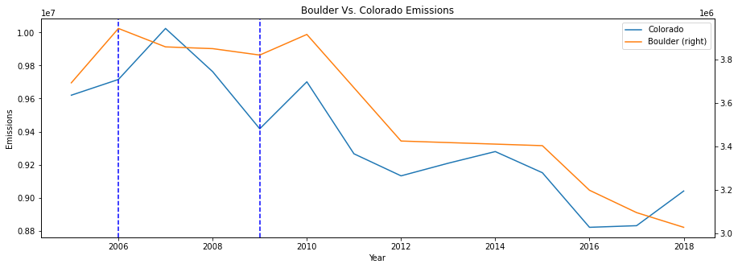

```python
ax = boulder_US_join[['Colorado','Boulder']].plot(secondary_y='Boulder',figsize=(15,5))
ax.set_title('Boulder Vs. Colorado Emissions')
ax.set_xlabel('Year')
ax.set_ylabel('Emissions')

ax.axvline(x=2006,c='b',ls='--')
ax.axvline(x=2009,c='b',ls='--')
```

This graph shows what I predicted would happen with Boulder and Colorado having relatively the same trend with some minor differences. There is a lot less fluctuation of ups and downs for Boulder as well compared to Colorado. The biggest discrepancy between emissions is between 2006 and 2009. Starting 2006 Boulder has a downwards trend that levels out in 2007-2009. Colorado starts 2006 on an upward trend that takes a sharp nosedive in 2007-2009. Boulder and Colorado both follow the upward trend heading into 2010. After 2010, Boulder and Colorado go up and down together until heading into the year 2018. The difference here is that Boulder emissions continue its downwards trend as Colorado starts to shoot up.

#### I now want to see Boulders emissions compared to the United States as a whole.

#### Here I plot out the US vs Boulder's emissions

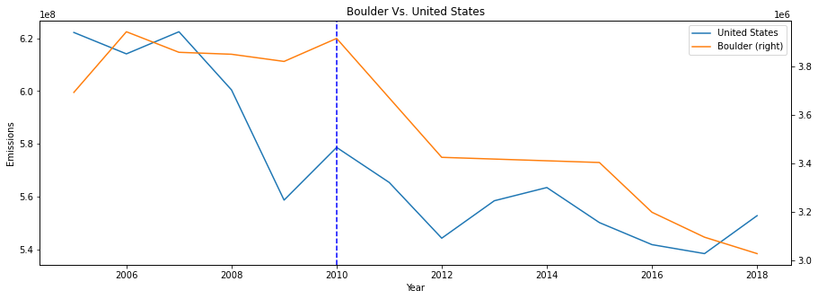

```python
ax = boulder_US_join[['United States','Boulder']].plot(secondary_y='Boulder',figsize=(15,5))
ax.set_title('Boulder Vs. United States')
ax.set_xlabel('Year')
ax.set_ylabel('Emissions')

ax.axvline(x=2010,c='b',ls='--')
```

This is different than what I predicted with the graph showing that Boulder and the US occasionally follow the same trend but not throughout. I would have expected more similarities early on since Boulder is under US restrictions and laws. I was also surprised to see that the US had an increase in emissions after 2012 with only a decrease with the first 2 years of the ACESA being put into place.

American Clean Energy and Security Act: https://en.wikipedia.org/wiki/American_Clean_Energy_and_Security_Act

#### Next I wanted to see how Boulder holds up to other states with places that were similar to the amount of emissions released in Colorado.

Wanted to look at states with similar emissions to Colorado to see if their emissions would follow the same trends. This would be interesting to see if the similar emissions would translate to similar trends which I predict it will.

#### Looked to see what each state’s emissions were.

```python
# boulder_US_join.sum(axis=0).sort_values(ascending=False)
```

#### Looked at the states closest to Colorado's emissions

```python
boulder_US_join.sum(axis=0).sort_values(ascending=False).iloc[23:26]
```

```
Arizona     1.335658e+08
Colorado    1.309703e+08
Iowa        1.193831e+08
dtype: float64
```

#### Graphed Boulder and Colorado vs Arizona and Iowa's emissions

Arizona is ranked one higher than Colorado in emissions and Iowa is ranked one less.

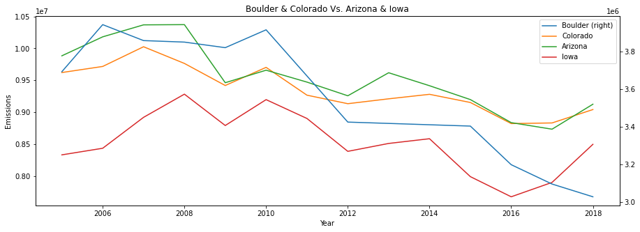

```python
ax = boulder_US_join[['Boulder','Colorado','Arizona','Iowa']].plot(secondary_y='Boulder',figsize=(15,5))

ax.set_title('Boulder & Colorado Vs. Arizona & Iowa')
ax.set_xlabel('Year')
ax.set_ylabel('Emissions')
```

Just as I predicted all these states follow quite closely the same trend. They all dipped and rose at around the same time with each to their own extremes. The only big difference I notice is that Colorado started to steadily decrease emissions a year earlier than Arizona and Iowa starting in 2007. Boulder in general also follows the same trends as these states. The only difference I can see that differs is that Bouler continues to decrease after 2017 in emissions. All the rest start to increase in their trends with Iowa increasing more rapidly. Boulder as well as these states seem to have the same effect on the total emissions released until the last couple of years where Boulder continued to decrease.

After looking into why these states increased in emissions around the same time I found out it was because of the increased demand for the rapidly changing weather. There was more of a demand for air conditioning as well as heating because of the changes in the weather. Also, there was an increase in the amount of oil used since it was at a very low point in price.

Article for emission increase: https://www.wri.org/blog/2018/12/new-global-co2-emissions-numbers-are-they-re-not-good#:~:text=Emissions%20are%20expected%20to%20increase,the%20E.U.%20have%20slowed%20recently.

#### Last thing I want to look at is how Boulder holds up compared to the state with the highest amount of emissions released

We here can see that the state with the highest emissions is Texas

```python
boulder_US_join.sum(axis=0).sort_values(ascending=False).head()
```

```
United States    8.011650e+09
Texas            1.068588e+09
California       5.323512e+08
Louisiana        3.532768e+08
Pennsylvania     3.523944e+08
dtype: float64
```

#### Graphed Boulder Vs Texas emissions

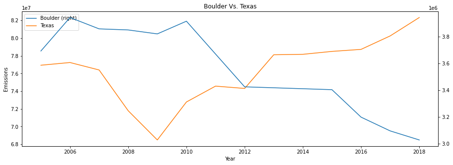

```python
ax = boulder_US_join[['Boulder','Texas']].plot(secondary_y='Boulder',figsize=(15,5))

ax.set_title('Boulder Vs. Texas')
ax.set_xlabel('Year')
ax.set_ylabel('Emissions')
```

This graph is nothing of what I would expect to see for the state with the highest emission rate. I wouldn't expect to see a major dip from 2005-2009 to then continually increasing upwards. It's confusing for me as well that Texas continued to increase after the ACESA went into effect. I found that Texas in 2009 through 2010 was in a major heatwave and drought. This caused an increased demand for energy meaning there were a lot more fossil fuels in Texas being burned at this time. Also, Texas has the second largest population and economy after California which also explains the large emission output overall. With global warming continuing to get worse, it seems that Texas continually has a demand for more energy to combat the increased temperature explaining the continual increase.

Texas Emissions Article: https://www.dallasfed.org/~/media/documents/research/swe/2019/swe1903c.pdf

# Conclusion

Before going into depth with this project what I expected to see was that Boulder would follow the same trends as Colorado and the US. I also expected to see Boulder follow more closely to Colorado overall since Boulder is directly impacted by Colorado's government. This is exactly what happened. Boulder dipped and rose around the same time Colorado but loosely followed the US. I assumed Boulder would have had a more common trend with the US overall but only did around 2010. Boulder emissions did not, however, dip as much as I thought it would in the early years with a sort of flatline in 2006-2010. Boulder being a city, I would expect the buzz around global warming would have caused more of an effect after 2005 than it did.

The limitations that I faced while looking at the emissions for Boulder and the US was that the Boulder data table has missing data the I had to interpolate to predict the missing data. This means that some of the data from Boulders data table isn't accurate and could lead to a misleading proejction of Boulder's emissions. The other limitation I faced was the limited years I could look at to compare. The Boulder data set only had data from 2005-2018. This limited the US data set to use data points from 2005 and on when it that had data starting in 1990. Because of this, the data used was more of a zoomed-in look at emissions from the US compared to Boulder. This means the data doesn't show the trends coming into the new century. This data would have been great to see for the facts the emphasis on restricting the output of our emissions was as much of a focus in the ‘90s.

Boulder as well as US and some other states looks to do a great job in decreasing its emissions. Boulder, particullary, except for the early years in this data table between 2005-2010 has continually decreased. Looking at states that were similar to Colorado; Arizona and Iowa, Boulder helped emissions to around the same impact. These places decreased the same times and around the same extent as Boulder. Boulder compared to a high emission state like Texas had done a way better job in decreasing its emissions. Texas, in the beginning, had a significant decrease, but shot up with global warming started to shows its effects. Boulder unlike all these states continued to decrease its emissions even after the nationwide increase in emissions. This is great as Boulder, despite the weather changes, continues to help lower the total emissions in the air. Boulder as well as the US have done a great job in the last decade to lower the total emissions released each year. Even though the last couple of years start to show an increase in the emission released, it doesn't take away that the decade average has decreased. With the American Clean Energy and Security Act being put into effect, Boulder and the US are doing a great job to start to combat global warming.